# Final Project

## Learning about the data

### EDA

Firstly, I needed to get a feel for that the data I needed to know what the data looked like.

```r
summary(df)
```

```
##    student_id        age           gender           gaming_hours
##  Min.   :   1   Min.   :16.00   Length:8000        Min.   :0.000
##  1st Qu.:2001   1st Qu.:18.00   Class :character   1st Qu.:2.130
##  Median :4000   Median :20.00   Mode  :character   Median :4.130
##  Mean   :4000   Mean   :19.98                      Mean   :4.086
##  3rd Qu.:6000   3rd Qu.:22.00                      3rd Qu.:6.060
##  Max.   :8000   Max.   :24.00                      Max.   :8.000
##   study_hours      sleep_hours      attendance     gaming_genre
##  Min.   : 1.000   Min.   :4.000   Min.   : 60.00   Length:8000
##  1st Qu.: 3.240   1st Qu.:5.240   1st Qu.: 69.78   Class :character
##  Median : 5.460   Median :6.505   Median : 79.69   Mode  :character
##  Mean   : 5.461   Mean   :6.493   Mean   : 79.89
##  3rd Qu.: 7.660   3rd Qu.:7.730   3rd Qu.: 90.10
##  Max.   :10.000   Max.   :9.000   Max.   :100.00
##  social_activity  device_usage    reaction_time_ms addiction_score
##  Min.   :0.000   Min.   : 1.100   Min.   :183.3    Min.   :-4.510
##  1st Qu.:1.288   1st Qu.: 5.560   1st Qu.:247.2    1st Qu.: 5.920
##  Median :2.500   Median : 7.610   Median :270.5    Median :10.005
##  Mean   :2.508   Mean   : 7.586   Mean   :271.1    Mean   : 9.908
##  3rd Qu.:3.760   3rd Qu.: 9.600   3rd Qu.:294.7    3rd Qu.:13.860
##  Max.   :5.000   Max.   :13.950   Max.   :347.9    Max.   :23.160
##  stress_level           grades
##  Length:8000        Min.   :  0.00
##  Class :character   1st Qu.: 49.88
##  Mode  :character   Median : 67.07
##                     Mean   : 66.18
##                     3rd Qu.: 83.99
##                     Max.   :118.63
```

```r
dim(df)
```

```
## [1] 8000   14
```

```r
head(df, 6)
```

```
##   student_id age gender gaming_hours study_hours sleep_hours attendance
## 1          1  22   Male         7.23        8.78        6.96      91.44
## 2          2  19   Male         0.07        8.72        7.63      63.63
## 3          3  23 Female         1.73        9.56        4.40      83.26
## 4          4  20 Female         6.62        1.68        7.83      75.04
## 5          5  22 Female         5.36        5.83        5.55      65.57
## 6          6  18   Male         7.16        6.84        8.03      68.11
##   gaming_genre social_activity device_usage reaction_time_ms addiction_score
## 1          FPS            3.25         9.36           235.84           14.69
## 2       Casual            1.02         3.21           328.71            2.47
## 3       Casual            3.46         5.56           313.61            4.73
## 4          RPG            1.46        11.78           241.84           14.54
## 5          FPS            1.01         8.23           249.31           12.48
## 6          RPG            3.74        10.90           242.75           18.75
##   stress_level   grades
## 1          Low 86.45955
## 2       Medium 98.23000
## 3         High 90.56000
## 4          Low 32.67000
## 5          Low 58.71000
## 6          Low 57.52000
```

```r
str(df)
```

```
## 'data.frame':    8000 obs. of  14 variables:
##  $ student_id      : int  1 2 3 4 5 6 7 8 9 10 ...
##  $ age             : int  22 19 23 20 22 18 22 23 20 19 ...
##  $ gender          : chr  "Male" "Male" "Female" "Female" ...
##  $ gaming_hours    : num  7.23 0.07 1.73 6.62 5.36 7.16 0.46 4.78 4.55 0.29 ...
##  $ study_hours     : num  8.78 8.72 9.56 1.68 5.83 6.84 7.4 6.79 7.93 4.24 ...
##  $ sleep_hours     : num  6.96 7.63 4.4 7.83 5.55 8.03 6.55 5.37 8.76 7.83 ...
##  $ attendance      : num  91.4 63.6 83.3 75 65.6 ...
##  $ gaming_genre    : chr  "FPS" "Casual" "Casual" "RPG" ...
##  $ social_activity : num  3.25 1.02 3.46 1.46 1.01 3.74 1.81 2.85 1 3.07 ...
##  $ device_usage    : num  9.36 3.21 5.56 11.78 8.23 ...
##  $ reaction_time_ms: num  236 329 314 242 249 ...
##  $ addiction_score : num  14.69 2.47 4.73 14.54 12.48 ...
##  $ stress_level    : chr  "Low" "Medium" "High" "Low" ...
##  $ grades          : num  86.5 98.2 90.6 32.7 58.7 ...
```

### Cleaning the Data

Next, I needed to know if there were any missing values and, if so, where the missing values are.

```r
any(is.na(df))
```

```
## [1] FALSE
```

```r
sum(is.na(df))
```

```
## [1] 0
```

```r
colSums(is.na(df))
```

```
##       student_id              age           gender     gaming_hours
##                0                0                0                0
##      study_hours      sleep_hours       attendance     gaming_genre
##                0                0                0                0
##  social_activity     device_usage reaction_time_ms  addiction_score
##                0                0                0                0
##     stress_level           grades
##                0                0
```

As there are no missing values, I don’t need to figure out what I need to do with them.

## Data Manipulation

I now needed to manipulate the data to make the data useable for my analysis.

This Manipulation is is to see the mean and median of the grades, gaming hours, attendance, and hours slept.

```r
df %>%
  group_by(gaming_genre) %>%
  summarise(mean(grades), median(grades),
            mean(gaming_hours), median(gaming_hours),
            mean(attendance), median(attendance),
            mean(sleep_hours), median(sleep_hours)
            )
```

```
## # A tibble: 3 × 9
##   gaming_genre `mean(grades)` `median(grades)` `mean(gaming_hours)`
##   <chr>                 <dbl>            <dbl>                <dbl>
## 1 Casual                 66.4             67.3                 4.14
## 2 FPS                    66.2             66.9                 4.04
## 3 RPG                    66.0             67.0                 4.09
## # ℹ 5 more variables: `median(gaming_hours)` <dbl>, `mean(attendance)` <dbl>,
## #   `median(attendance)` <dbl>, `mean(sleep_hours)` <dbl>,
## #   `median(sleep_hours)` <dbl>
```

This shows that, for the most part, in this data, all the averages and medians are almost the same for each category.

The next thing I wanted to see what percentage of the types of gamers in the data.

```r
df %>%
  count(gaming_genre) %>%
  mutate(pct = n / sum(n)) %>%
  arrange(desc(pct))
```

```
##   gaming_genre    n      pct
## 1          FPS 3187 0.398375
## 2          RPG 2408 0.301000
## 3       Casual 2405 0.300625
```

This is showing that data fairly even across the board for what genres people play, but there are a few more people that first person shooters (FPS), role-playing games (RPG), and casual games.

Now I wanted to know what the percentage of people playing games for more than 2 hours is.

```r
df %>%
  summarise(
    n= sum(gaming_hours > 2, na.rm = TRUE),
    pct = mean(gaming_hours > 2, na.rm = TRUE)
  )
```

```
##      n   pct
## 1 6096 0.762
```

It seems that in this data, about 76% of people in this data have a play time of over 2 hours.

The next thing I needed to do was make some categories to make it easier to see at a glance if someone has a low, moderate, or high play time.

```r
df <- df %>% mutate(
  PlayTimeCategory = case_when(
    gaming_hours < 1 ~ "Low Play Time",
    gaming_hours <= 3 ~ "Moderate Play Time",
    TRUE ~ "High Play Time."
  )
)

print(df %>%
        group_by(PlayTimeCategory) %>%
        count())
```

```
## # A tibble: 3 × 2
## # Groups:   PlayTimeCategory [3]
##   PlayTimeCategory       n
##   <chr>              <int>
## 1 High Play Time.     5126
## 2 Low Play Time        974
## 3 Moderate Play Time  1900
```

After getting the count for each category, I made it look like in this data, most of the people have a play time that is over 3 hours, next is people that have a moderate play time of 1-3 hours, and the fewest people have a play time that is less than 1 hour.

Finally, the last data manipulation I did was creating a column that shows the students’ letter grade.

```r
df <- df %>% mutate(
  LetterGrade = case_when(
    grades <= 60.0 ~ "F",
    grades <= 70.0 ~ "D",
    grades <= 80.0 ~ "C",
    grades <= 90.0 ~ "B",
    TRUE ~ "A."
  )
)

print(df %>%
        group_by(LetterGrade) %>%
        count())
```

```
## # A tibble: 5 × 2
## # Groups:   LetterGrade [5]
##   LetterGrade     n
##   <chr>       <int>
## 1 A.           1375
## 2 B            1076
## 3 C            1196
## 4 D            1222
## 5 F            3131
```

## Z-Test

The next thing that I needed to do with my data was run a Z-test. For that test, I would like to know if Men and Women have the same play time on average.

### Hypothesis

Null Hypothesis: Men and women have no difference in their average play time.

Alternative Hypothesis: There is a difference between men’s and women’s average play time.

### getting set up for the Z-Test

First, I needed to know what the standard deviation for hours playing games is in my data set.

```r
df %>%
  summarise(sd(gaming_hours))
```

```
##   sd(gaming_hours)
## 1         2.308801
```

It would seem that we have a standard deviation of about 2.

After that, I need to set up new data frames, one that only has the columns of people’s gender and the gaming hours. Then I need to split that data set into two different data frames, one for men and one for women.

```r
games <- df %>%
  select(gender, gaming_hours)

male_games <- games$gaming_hours[games$gender =="Male"]
fem_games <- games$gaming_hours[games$gender =="Female"]
```

Next, I need to set my sigma, alpha of 0.05, means, and the length for the Z-Test

```r
sigma_male <- 2
sigma_female <- 2
alpha <- 0.05

mean_male <- mean(male_games)
mean_girl <- mean(fem_games)

n_male <- length(male_games)
n_fem <- length(fem_games)
```

### The Z-Test

Finally, with all the setup done, I can run my Z-Test.

```r
z_stat <- (mean_male - mean_girl) /
  sqrt((sigma_male^2 / n_male) + (sigma_female^2 / n_fem))

z_stat
```

```
## [1] -0.204603
```

We got a Z-score of -0.20

But the Z-score does not tell us much, so we need to get the P-Value from the Z-score.

```r
p_val <- 2 * (1 - pnorm(abs(z_stat)))

p_val
```

```
## [1] 0.8378823
```

```r
if (p_val <= alpha) {
  print("Reject the null hypothesis.")
} else {
  print("Fail to reject the null hypothesis.")
}
```

```
## [1] "Fail to reject the null hypothesis."
```

So the Results of our Z-Test show there is little to no difference in the amount of time men and women play games.

## Graphs

For my first graph, I wanted to know how many students are in each letter grade and compare their stress levels vs how many hours they play games.

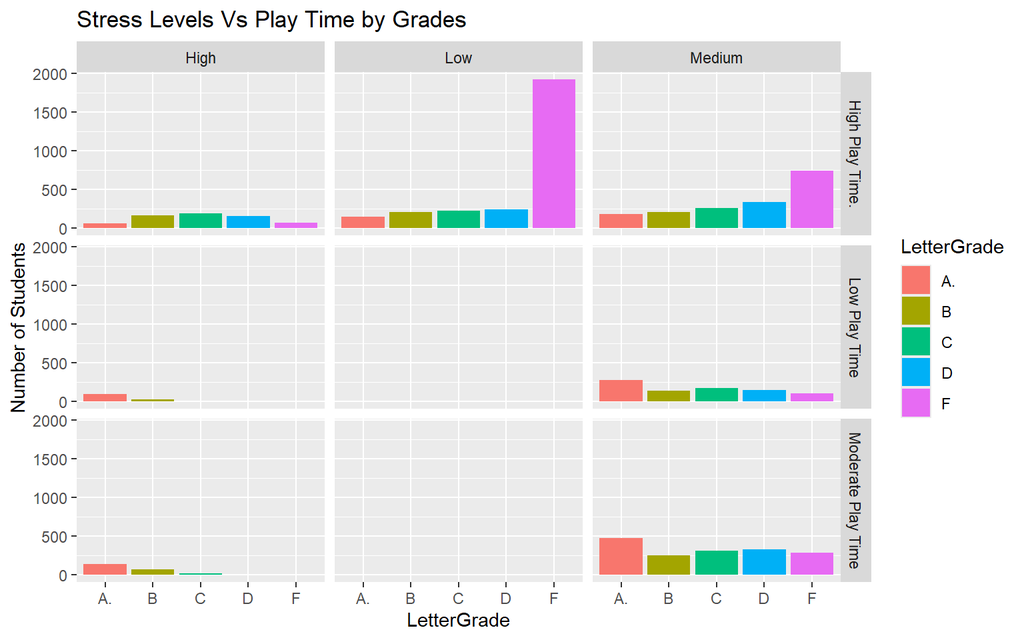

```r
ggplot(df, aes(LetterGrade, fill = LetterGrade))+
  geom_bar()+
  facet_grid(PlayTimeCategory~stress_level)+
  labs(title = "Stress Levels Vs Play Time by Grades", y = "Number of Students")
```

The next graph I wanted to see was a comparison of the students’ addiction score and the number of hours they play. I also colored the scatter plot with the students’ letter grades to see if there was a trend for their grades, and finally, I wanted to compare all the data to the gaming genres.

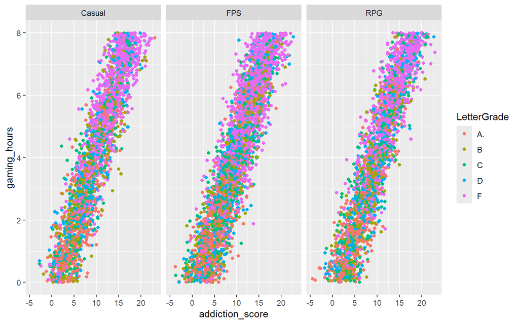

```r
ggplot(df, aes(addiction_score, gaming_hours, color = LetterGrade))+
  geom_point()+
  facet_wrap(~gaming_genre)
```

Looking at the graph, it shows that when comparing the genres of games, there doesn’t seem to be too many differences, and with the grades, the dose seem that the more hours played and a higher addiction score do seem to lower the grade, and the lower addiction score and lower hours played do seem to help their grade.

Another graph I wanted to see was how the average sleep time affected the students’ grades and what their play time was.

```
## `summarise()` has regrouped the output.
## ℹ Summaries were computed grouped by LetterGrade and PlayTimeCategory.
## ℹ Output is grouped by LetterGrade.
## ℹ Use `summarise(.groups = "drop_last")` to silence this message.
## ℹ Use `summarise(.by = c(LetterGrade, PlayTimeCategory))` for per-operation
##   grouping (`?dplyr::dplyr_by`) instead.
```

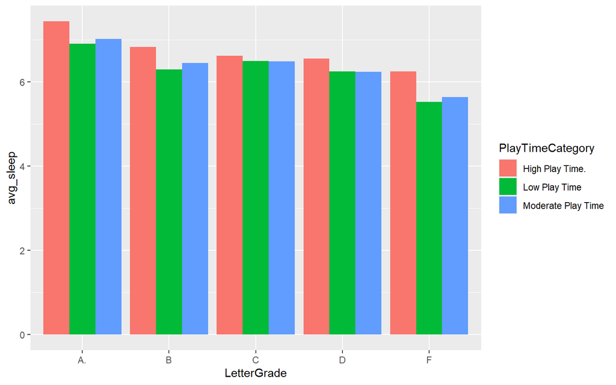

```r
df %>%
  group_by(LetterGrade, PlayTimeCategory) %>%
  summarise(avg_sleep = mean(sleep_hours, na.rm = TRUE)) %>%
  ggplot(aes(x = LetterGrade, y = avg_sleep, fill = PlayTimeCategory)) +
  geom_col(position = "dodge")
```

From looking at the data, it does seem that the more sleep on average the students got, the better their grades are. Another interesting thing is that the highest bar is the one with a high sleep average, and an A is also colored for High play time, meaning that when the students get enough sleep, they get a good grade and also play games for hours.

##Correlation heat map

The final thing I wanted to do was make a correlation heat map of all the numeric values in my data.

### Setting up for the heat map

I needed to make another data frame of just the numeric data from the original data frame and then make a correlation.

```r
numdf = df %>%
  select(age, gaming_hours, study_hours, sleep_hours, attendance, social_activity, device_usage, reaction_time_ms, addiction_score, grades)


corr_mat <- round(cor(numdf),2)
```

### The Heat Map

Finally, I created the heat map.

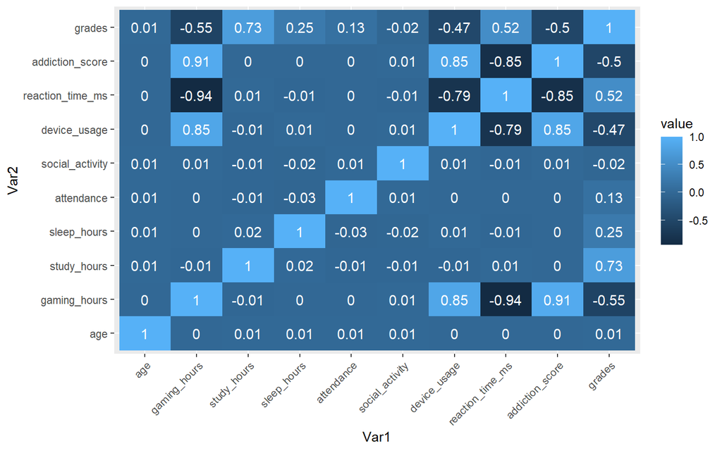

```r
melted_corr_mat <- melt(corr_mat)



ggplot(data = melted_corr_mat, aes(x=Var1, y=Var2, fill=value)) +
  geom_tile() +
  geom_text(aes(Var2, Var1, label = value), color = "white", size = 4) +
  theme(axis.text.x = element_text(angle = 45, hjust = 1))
```

Looking at the map, it seems that not many things correlate, but when they do correlate, almost all of the correlations are high to moderate correlation ether positive or negative. Some of the standout ones tho are the negative strong correlation between reaction time and gaming hours, another one suppring one is that there is a moderate correlation between grades and reaction time.